# Unsupervised Learning on Global Cancer Patient Data (2015-2024)

This notebook performs an unsupervised learning analysis on the **Global Cancer Patient Dataset (2015-2024)**, sourced from https://www.kaggle.com/datasets/zahidmughal2343/global-cancer-patients-2015-2024. The dataset comprises cancer patient records with numerical predictors (e.g., Age, Genetic_Risk, Air_Pollution, Alcohol_Use, Smoking, Obesity_Level, Treatment_Cost_USD, Survival_Years) and categorical variables (e.g., Gender, Country_Region, Cancer_Type, Cancer_Stage).

The analysis aims to:

- Identify key risk factors using PCA and SVD.
- Reconstruct missing data via matrix completion.
- Detect anomalies in patient records.
- Determine top predictors of patient outcomes.
- Visualize correlations among features.
- Group patients into risk profiles using clustering.

Techniques applied include PCA, SVD, Isolation Forest, hierarchical clustering, and K-Means clustering.

```python
# Import libraries for data manipulation, numerical operations, and visualization
import pandas as pd
import numpy as np
import matplotlib.pyplot as plt
import seaborn as sns

# Import scikit-learn tools for preprocessing and unsupervised learning
from sklearn.preprocessing import StandardScaler, LabelEncoder
from sklearn.decomposition import PCA
from sklearn.cluster import KMeans, AgglomerativeClustering
from sklearn.impute import SimpleImputer
from sklearn.ensemble import IsolationForest
from sklearn.metrics import silhouette_score

# Import scipy for hierarchical clustering and SVD
from scipy.cluster.hierarchy import linkage, dendrogram
from numpy.linalg import svd

# Set random seed for reproducibility
np.random.seed(42)
```

# 2. Load and Inspect the Dataset

Load the dataset and inspect its structure and missing values.

```python
# Load the dataset from a CSV file
data = pd.read_csv('dataset.csv')

# Drop Patient_ID as it’s an identifier, not a feature for analysis
data = data.drop('Patient_ID', axis=1)

# Check for missing values
print("Missing Values per Column:")
print(data.isnull().sum())

# Display first few rows
print("\nFirst 5 Rows of the Dataset:")
print(data.head())
```

```
Missing Values per Column:
Age                      0
Gender                   0
Country_Region           0
Year                     0
Genetic_Risk             0
Air_Pollution            0
Alcohol_Use              0
Smoking                  0
Obesity_Level            0
Cancer_Type              0
Cancer_Stage             0
Treatment_Cost_USD       0
Survival_Years           0
Target_Severity_Score    0
dtype: int64

First 5 Rows of the Dataset:
   Age  Gender Country_Region  Year  Genetic_Risk  Air_Pollution  Alcohol_Use  \
0   71    Male             UK  2021           6.4            2.8          9.5
1   34    Male          China  2021           1.3            4.5          3.7
2   80    Male       Pakistan  2023           7.4            7.9          2.4
3   40    Male             UK  2015           1.7            2.9          4.8
4   43  Female         Brazil  2017           5.1            2.8          2.3

   Smoking  Obesity_Level Cancer_Type Cancer_Stage  Treatment_Cost_USD  \
0      0.9            8.7        Lung    Stage III            62913.44
1      3.9            6.3    Leukemia      Stage 0            12573.41
2      4.7            0.1      Breast     Stage II             6984.33
3      3.5            2.7       Colon      Stage I            67446.25
4      6.7            0.5        Skin    Stage III            77977.12

   Survival_Years  Target_Severity_Score
0             5.9                   4.92
1             4.7                   4.65
2             7.1                   5.84
3             1.6                   3.12
4             2.9                   3.62
```

# 3. Data Preprocessing

Prepare and clean the data logically:

- Separate numerical and categorical features.
- Impute missing values (median for numerical, most frequent for categorical).
- Standardize numerical features.
- Encode categorical variables for clustering.

```python
# Define numerical and categorical columns
numerical_cols = ['Age', 'Genetic_Risk', 'Air_Pollution', 'Alcohol_Use',
                  'Smoking', 'Obesity_Level', 'Treatment_Cost_USD', 'Survival_Years']
categorical_cols = ['Gender', 'Country_Region', 'Year', 'Cancer_Type', 'Cancer_Stage']

# Ordinal encoding for Cancer_Stage
stage_mapping = {'Stage 0': 0, 'Stage I': 1, 'Stage II': 2, 'Stage III': 3, 'Stage IV': 4}
data['Cancer_Stage'] = data['Cancer_Stage'].map(stage_mapping)

# Impute missing values
num_imputer = SimpleImputer(strategy='median')
data[numerical_cols] = num_imputer.fit_transform(data[numerical_cols])

cat_imputer = SimpleImputer(strategy='most_frequent')
data[categorical_cols] = cat_imputer.fit_transform(data[categorical_cols])

# Standardize numerical features
scaler = StandardScaler()
X_num_scaled = scaler.fit_transform(data[numerical_cols])
X_num_scaled_df = pd.DataFrame(X_num_scaled, columns=numerical_cols, index=data.index)

# Encode categorical features for clustering
label_encoders = {}
for col in categorical_cols:
    le = LabelEncoder()
    data[col] = le.fit_transform(data[col])
    label_encoders[col] = le

# Combine standardized numerical and encoded categorical features
X_full = pd.concat([X_num_scaled_df, data[categorical_cols].reset_index(drop=True)], axis=1)

print("\nShape of Combined Feature Set for Clustering:", X_full.shape)
```

```
Shape of Combined Feature Set for Clustering: (50000, 13)
```

# 4. Principal Component Analysis (PCA)

Apply PCA to explore data structure:

- Tune number of components using scree and cumulative variance plots.
- Evaluate variance explained.
- Visualize PCA results and loadings.

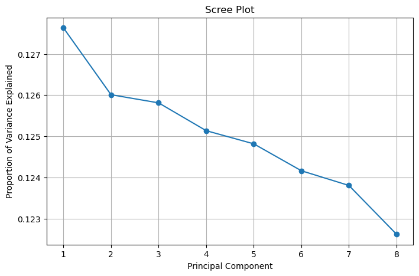

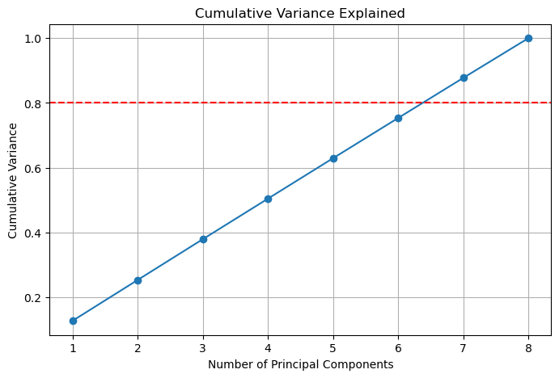

```
PCA Loadings:
                         PC1       PC2       PC3       PC4       PC5  \
Age                -0.154106 -0.058981 -0.526429 -0.358363  0.616642
Genetic_Risk       -0.057917  0.457372 -0.304103  0.644186  0.347965
Air_Pollution       0.446597 -0.261393  0.028223 -0.250576  0.426035
Alcohol_Use         0.307908  0.125153  0.600446 -0.002611  0.334909
Smoking             0.379645 -0.354170 -0.438960 -0.000557 -0.328244
Obesity_Level       0.517016  0.443733 -0.030512 -0.147603  0.017290
Treatment_Cost_USD -0.434087  0.334099  0.095694 -0.556327 -0.054209
Survival_Years      0.280666  0.519023 -0.257464 -0.250034 -0.306628

                         PC6       PC7       PC8
Age                -0.254471  0.298865  0.181377
Genetic_Risk        0.012517 -0.201503 -0.343747
Air_Pollution       0.560124 -0.297078 -0.291788
Alcohol_Use        -0.445040  0.353738 -0.305993
Smoking            -0.483953 -0.125252 -0.424387
Obesity_Level      -0.243512 -0.432723  0.515976
Treatment_Cost_USD -0.153226 -0.416648 -0.425765
Survival_Years      0.326039  0.529299 -0.206293
```

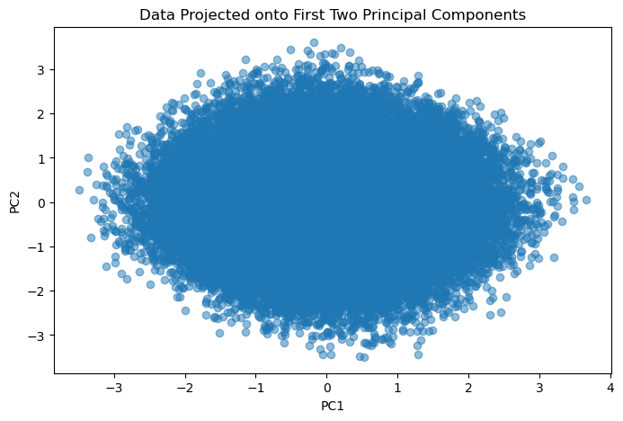

```python
# Fit PCA
pca = PCA()
X_pca = pca.fit_transform(X_num_scaled_df)

# Scree plot for tuning number of components
plt.figure(figsize=(8, 5))
plt.plot(range(1, len(pca.explained_variance_ratio_) + 1),
         pca.explained_variance_ratio_, marker='o')
plt.title('Scree Plot')
plt.xlabel('Principal Component')
plt.ylabel('Proportion of Variance Explained')
plt.grid(True)
plt.show()

# Cumulative variance plot
cum_var = np.cumsum(pca.explained_variance_ratio_)
plt.figure(figsize=(8, 5))
plt.plot(range(1, len(cum_var) + 1), cum_var, marker='o')
plt.title('Cumulative Variance Explained')
plt.xlabel('Number of Principal Components')
plt.ylabel('Cumulative Variance')
plt.axhline(y=0.8, color='r', linestyle='--')  # 80% threshold
plt.grid(True)
plt.show()

# PCA loadings table
loadings = pd.DataFrame(pca.components_.T,
                        columns=[f'PC{i+1}' for i in range(pca.n_components_)],
                        index=numerical_cols)
print("\nPCA Loadings:")
print(loadings)

# Visualize first two principal components
plt.figure(figsize=(8, 5))
plt.scatter(X_pca[:, 0], X_pca[:, 1], alpha=0.5)
plt.title('Data Projected onto First Two Principal Components')
plt.xlabel('PC1')
plt.ylabel('PC2')
plt.show()
```